# Network metrics dependency on link sampling effort

In this R Notebook we will study how sampling effort affects the values of different network metrics for a specific size Madingley aggregated size. Let’s start by importing useful libraries:

```r
# Loading packages
library(igraph) # R famous graph library
library(data.table) # A really fast data frame
library(ggplot2) # Nice plots in R
library(gridExtra)
library(NetIndices)
library(parallel)
library(latex2exp)

# Loading Mandingley reading functions
source('../main_code/network_reading.R')
source('../main_code/network_aggregation.R')
source('../main_code/network_sampling.R')
source('../main_code/network_functions.R')
source('../main_code/misc.R')
```

The followin represents the main parameters of the simulation

```r
# Number of nodes to perform cohort aggregation.
simulation_S           <- 100

# Link attribute to be used as the weight in the network to perform the poisson sampling
simulation_attr_weight <- "biomass.flow"

# The number of different link sizes to plot (i.e. connectance)
simulation_link_size   <- floor(sapply(seq(0,13), function(x) 20*1.5^x))

# The number of trials for each different sampling link size
simulation_trials      <- 1000

# Plot null model data
simulation_use_null_model       <- FALSE

# Use parallelism (only possible in non windows computers)
simulation_use_parallelism      <- FALSE
simulation_cores                <- 6 # If previous value is TRUE

# Just a simple function to make use of a paraller lapply when enabled
sim_lapply <- function(...){
  if(simulation_use_parallelism == TRUE){
    mclapply(mc.cores = simulation_cores, mc.silent = FALSE, ...)
  } else{
    lapply(...)
  }
}

set.seed(101) ## for reproducibility
```

### Loading Madingley data

Let’s continue by loading the full Madingley network at different time steps (an snapshot of the simulation), from 1200 to 1223 (around ~1000 time steps are required for the simulation to become stable):

```r
node_file <- '../../data/madingley_data/original_nodes.txt'
edge_file <- '../../data/madingley_data/original_edges.txt'

# 1200 to 1223
madingley_times <- unique(fread(input=node_file, header = T, sep = '\t')$TimeStep)

# Getting all mandingley objects (24 objects), each one representing a different time step and containing a different graph
madingley_full_objects <- sim_lapply(madingley_times,  read.madingley.data, file_nodes=node_file, file_edges=edge_file, include_source_node = FALSE)
```

### Generating the cohort aggregation graphs

Now we generate our initial set of cohort agrregations for each snapshot of the Madingley output. For this part we also need to decide, we need to fix the number of nodes to which the aggregation will be performed ($S$).

```r
S = simulation_S

kmeans_snapshots_agg_graphs  <- sim_lapply(madingley_full_objects, function(x) cohort.aggregation(x, S, node.kmeans.aggregation)@G)
jaccard_snapshots_agg_graphs <- sim_lapply(madingley_full_objects, function(x) cohort.aggregation(x, S, node.jaccard.aggregation)@G)
```

### Generating the sampling graphs

Now for each different link size connectance, we will need to generate a set of different sampling networks according to the initial parameters. The main idea is that we will use any of the previous set of cohort aggregated graphs as the initial set to sample. The snapshot to be used will be chosen randomly with replacement:

```r
# A function to generate 'N_trials' sampled poisson graphs with 'L' links
# from a set of cohort aggregated graphs 'shapshot_agg_graphs'
agg_sampling_effort_graphs <- function(L, snapshots_agg_graphs, N_trials = simulation_trials) {

  snapshot_index = sample.int(length(madingley_times), N_trials, replace = TRUE)
  sample_graphs <- lapply(snapshot_index,
                          function(x) sampling.poisson(n_links_sampled = L,
                                                       G = snapshots_agg_graphs[[x]],
                                                       lambda_rate = simulation_attr_weight)
  )

  return(sample_graphs)
}
```

### Extracting the network metrics

Now we can create a function that will be used to extract all network metrics for the aggregated snapshots:

```r
# A function to generate some network metrics
calculateMetrics <-function (g)
{
  S <- vcount(g)
  L <- ecount(g)
  connect <- S/(L * L)

  clust = clusters(g,mode = "weak")

  mean.pl <-average.path.length(g, directed = F)
  le.mod <- modularity(walktrap.community(g))
  transglobal <- transitivity(g, type = 'global')
  n.components = clust$no
  large.component = max(clust$csize)

  variables = c("mean.pl", "le.mod", "transglobal", "n.components", "large.component")

  return(list(mean.pl = mean.pl, le.mod = le.mod, transglobal = transglobal,
              n.components = n.components, large.component = large.component))
}

# A function to generate the expected network metrics
get_sample_effort_network_metrics <- function(snapshots_agg_graphs, N_trials = simulation_trials)
{

  # Creates a random graph with S nodes and L expected links.
  get_metric_summary <- function(L) {
    print(paste("Calculating metrics for network:", L))
    graphs <- agg_sampling_effort_graphs(L, snapshots_agg_graphs, N_trials)
    metrics <- lapply(graphs,calculateMetrics)
    metrics_dt <- rbindlist(metrics, fill=TRUE)
    return(metrics_dt)
  }

  metrics <- sim_lapply(simulation_link_size, get_metric_summary)

  return(metrics)
}

# metrics for a bernoulli null model
get_null_metrics <- function(N_trials){

  i <- 0
  get_metric_summary <- function(L) {
    i <<- i+1
    print(paste("Calculating metrics for network:", i))
    graphs <- replicate(N_trials, list(null_bernoulli_graph(simulation_S, L)))
    metrics <- lapply(graphs,calculateMetrics)
    metrics_dt <- rbindlist(metrics, fill=TRUE)
    return(metrics_dt)
  }

  metrics <- sim_lapply(simulation_link_size, get_metric_summary)
  return(metrics)
}
```

Using the previous function we can finally extract all network metrics for the Madingley aggregated sampled food webs. For this part, we will extract results for both methods of cohort aggregation: i) jaccard trophic similarity, and k-means mass aggregation:

```r
# this part is very expensive, therefore, only do if the data is not there already
if(file.exists('mettrics_vs_sampling_effort1000.RData')){
  load('mettrics_vs_sampling_effort1000.RData')
}else{
  N_trials <- simulation_trials
  jaccard_metrics    <- get_sample_effort_network_metrics(jaccard_snapshots_agg_graphs, N_trials)
  kmeans_metrics     <- get_sample_effort_network_metrics(kmeans_snapshots_agg_graphs, N_trials)
  null_model_metrics <- get_null_metrics(N_trials)
  save(jaccard_metrics, kmeans_metrics, null_model_metrics, file = 'mettrics_vs_sampling_effort1000.RData')
}

# Getting means and standard deviation for all N_trials of each corresponding study
jacc_metrics_mean_dt   <- rbindlist(lapply(jaccard_metrics, function(x) x[, lapply(.SD, mean, na.rm=TRUE)]), fill=TRUE)
jacc_metrics_std_dt    <- rbindlist(lapply(jaccard_metrics, function(x) x[, lapply(.SD, sd, na.rm=TRUE)]), fill=TRUE)

kmeans_metrics_mean_dt <- rbindlist(lapply(kmeans_metrics, function(x) x[, lapply(.SD, mean, na.rm=TRUE)]), fill=TRUE)
kmeans_metrics_std_dt  <- rbindlist(lapply(kmeans_metrics, function(x) x[, lapply(.SD, sd, na.rm=TRUE)]), fill=TRUE)

null_mean_dt           <- rbindlist(lapply(null_model_metrics, function(x) x[, lapply(.SD, sd)]), fill=TRUE)
null_std_dt            <- rbindlist(lapply(null_model_metrics, function(x) x[, lapply(.SD, sd)]), fill=TRUE)
```

### Results

Now we can create the plot function:

```r
get_plot <- function(use_null = FALSE)
{
  connectance <- simulation_link_size/(simulation_S*simulation_S)

  jacc_metrics_mean_dt$connect      <- connectance
  kmeans_metrics_mean_dt$connect    <- connectance
  null_mean_dt$connect              <- connectance
  jacc_metrics_mean_dt$agg_method   <- 'Jaccard Trophic Similarity'
  kmeans_metrics_mean_dt$agg_method <- 'Mass A/J K-means'
  null_mean_dt$agg_method           <- 'Null Model'

  if(use_null == TRUE){
    mean_dt <- rbind(jacc_metrics_mean_dt,kmeans_metrics_mean_dt,null_mean_dt)
  }else{
    mean_dt <- rbind(jacc_metrics_mean_dt,kmeans_metrics_mean_dt)
  }

  labels = c("connectance", "agg_method","number of components", "average path length", "modularity", "clustering")
  variables = c("connect","agg_method", "n.components", "mean.pl", "le.mod", "transglobal")

  mean_dt <- mean_dt[,variables,with=FALSE]

  colnames(mean_dt) <- labels

  mean_dt_melted <- melt(mean_dt, id = c("connectance","agg_method"), measure = labels[3:6])

  q <- qplot(data=mean_dt_melted, x=connectance, y=value, log='x', size=I(2),
            shape=agg_method, group = agg_method, color = agg_method) +
       facet_wrap(~variable, scales = "free_y", ncol=2) +
       labs(y = "metric value", x = TeX("S / L^2")) +
       theme_bw() +
       theme(legend.title=element_blank()) +
       theme(axis.text=element_text(size=8),axis.title=element_text(size=12)) +
       theme(legend.position="top")

  return(q)

}
```

Now we can see how a different set of metrics changes according to the connectance for the two set of aggregated methods in the following figure.

```r
q<-get_plot(use_null = simulation_use_null_model)
pdf("figure04_metrics.pdf", width = 10, height = 6) # Open a new pdf file
q
dev.off()
```

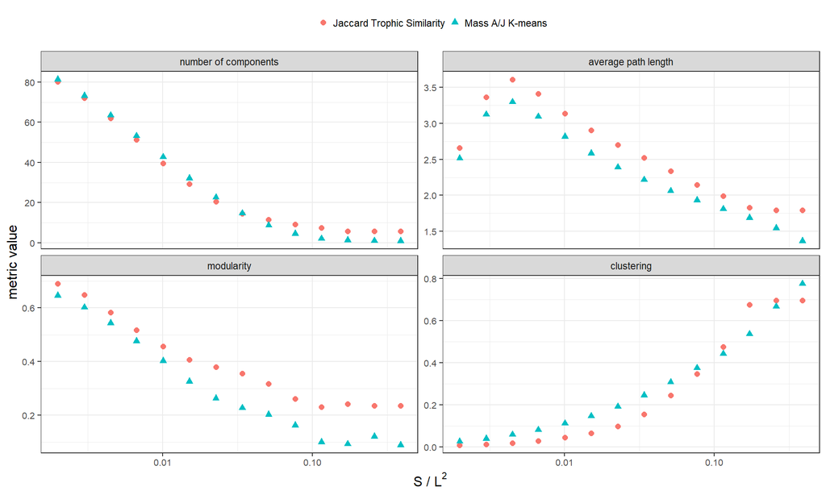

```r
q
```